# Stat 202: Lecture 10 (covers pp. 124-137)

Nathan VanHoudnos  
10/15/2014

### Agenda

1. Homework comments
2. Checkpoint #11 results
3. Lecture 10 (covers pp. 124-137)

### Homework comments

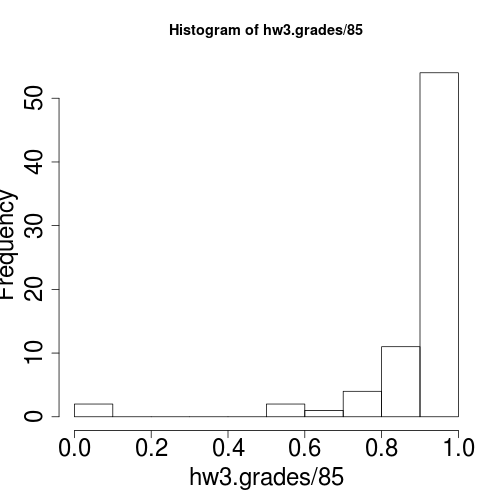

```r
mean(hw3.grades/85)
```

```
[1] 0.9068
```

```r
median(hw3.grades/85)
```

```
[1] 0.9412
```

### Agenda

1. Homework comments
2. Checkpoint #11 results
3. Lecture 10 (covers pp. 124-137)

### Checkpoint #11 results

- 69/76 students
- on average 86% percent correct

### Checkpoint #11 Question 1

(i) 31% of all Dalmatians have blue eyes.  
(ii) 38% of all Dalmatians are deaf.  
(iii) 42% of blue-eyed Dalmatians are deaf.

What is the probability that a randomly chosen Dalmatian is blue-eyed and deaf?

\( P(B \text{ and } D) = ? \)

Must use the **general multiplication rule**:

\( P(B \text{ and } D) = P(D|B)P(B) = .42 * .31 = .13 \)

Note that: \( P(D)P(B) = .38 * .31 = .118 \ne P(B \text{ and } D) \)

### Agenda

1. Homework comments
2. Checkpoint #11 results
3. Lecture 10 (covers pp. 124-137)
   - **Checkpoint 12**: Random variables (RVs) and distributions
   - **Checkpoint 13**: Expection and variance rules

### Random Variables

> **random variable:** A random variable assigns a unique numerical value to the outcome of a random experiment.

Consider the random experiment of flipping a coin twice. \( S = \{ HH, HT, TH, TT \} \)

Let \( X \) be the number of tails.

- HH implies \( X = 0 \)
- HT implies \( X = 1 \)
- TH implies \( X = 1 \)
- TT implies \( X = 2 \)

### Random Variables

Consider getting data from a random sample on the number of ears in which a person wears one or more earrings.

Let \( X \) be the number of ears in which a randomly selected person wears an earring.

If the selected person

- does not wear any earrings, then \( X = 0 \).
- wears earrings in either the left or the right ear, then \( X = 1 \).
- wears earrings in both ears, then \( X = 2 \).

### Random Variables

Assume we choose a lightweight male boxer at random and record his exact weight. According to the boxing rules, a lightweight male boxer must weigh between 130 and 135 pounds, so the sample space here is \( S = [130, 135] \).

Let \( X \) be the weight of the boxer.

In this case, \( X \in [130,135] \).

### Random Variables

> **random variable:** A random variable assigns a unique numerical value to the outcome of a random experiment.

**Always** arise from a random experiment!

Two types of random variables:

- **discrete** : possible values are from a list
  - “Things you count.”
- **continuous** : possible values are from an interval
  - “Things you measure.” (w/ or w/o rounding)

### Random Variables

Number of ears pierced?

- **discrete**

Weight of a lightweight boxer?

- **continuous**

Number of hours watching TV (rounded to the nearest hour)?

- **continuous** (rounded is still continuous)

### Random Variables

How many days per week do you drink soda?

- **discrete**

How many ounces of soda per week do you drink?

- **continuous**

The average weight of 18 year old males at basic training.

- **continuous**

### Distribution of a discrete RV

Consider the random experiment of flipping a coin twice. \( S = \{ HH, HT, TH, TT \} \)

Let \( X \) be the number of tails. Recall: \[ \begin{aligned} HH \rightarrow X & = 0 & HT \rightarrow X & = 1 \\ TH \rightarrow X & = 1 & TT \rightarrow X & = 2 \end{aligned} \]

What is the probability of \( X=0 \)?

\[ P( X = 0) = P( HH ) = \frac{1}{4} \]

### Distribution of a discrete RV

Consider the random experiment of flipping a coin twice. \( S = \{ HH, HT, TH, TT \} \)

Let \( X \) be the number of tails. Recall: \[ \begin{aligned} HH \rightarrow X & = 0 & HT \rightarrow X & = 1 \\ TH \rightarrow X & = 1 & TT \rightarrow X & = 2 \end{aligned} \]

What is the probability of \( X=1 \)? \[ \begin{aligned} P( X = 1) & = P( HT \text{ or } TH ) \\ & = P( HT ) + P(TH ) \\ & = \frac{1}{4} + \frac{1}{4} = \frac{1}{2} \end{aligned} \]

### Distribution of a discrete RV

Consider the random experiment of flipping a coin twice. \( S = \{ HH, HT, TH, TT \} \)

Let \( X \) be the number of tails. Recall: \[ \begin{aligned} HH \rightarrow X & = 0 & HT \rightarrow X & = 1 \\ TH \rightarrow X & = 1 & TT \rightarrow X & = 2 \end{aligned} \]

The distribution of \( X \):

```r
x        |   0 |   1 |   2 |
---------+-----+-----+-----|
P(X = x) | 1/4 | 1/2 | 1/4 |
```

### Comment on notation

The distribution of \( X \):

```r
x        |   0 |   1 |   2 |
---------+-----+-----+-----|
P(X = x) | 1/4 | 1/2 | 1/4 |
```

\( P(X = x) \) is read as

- the probability that
- the random variable \( X \) is
- equal to the value \( x \).

**Random variables** are **CAPITALIZED**.

**Values** (AKA realizations) are **lower case**.

### Reprise: Rules

Let \( X \) be a random variable and \( x \) a realization of that random variable.

1. \( 0 \le P(X = x) \le 1 \) for all \( x \).

For example:

```r
x        |   0 |   1 |   2 |
---------+-----+-----+-----|
P(X = x) | 1/4 | 1/2 | 1/4 |
```

\[ \begin{aligned} 0 & \le P(X = 0) = \frac{1}{4} \le 1 \\ 0 & \le P(X = 1) = \frac{1}{2} \le 1\\ \end{aligned} \]

### Reprise: Rules

Let \( X \) be a random variable and \( x \) a realization of that random variable.

1. \( 0 \le P(X = x) \le 1 \) for all \( x \).
2. \( \sum_{x\in S} P(X = x) = 1 \) \( \quad \)

For example:

\[ \begin{aligned} \sum_{x \in S} P(X = x) & = P(X=0) + P(X=1) + P(X=2) \\ & = 1/4 + 1/2 + 1/4 = 1 \end{aligned} \]

**Note:** If summation notation is unfamiliar, check out Khan Academy [here](https://www.khanacademy.org/math/integral-calculus/sequences_series_approx_calc/calculus-series/v/sigma-notation-sum) and [here](https://www.khanacademy.org/math/integral-calculus/sequences_series_approx_calc/calculus-series/v/properties-to-find-sum).

### A further example

A coin is tossed three times. Let the random variable X be the number of tails. Find the probability distribution of X.

1. Write out the sample space.
2. Define each possible realization of \( X \) as an event.
3. Find the probabilities of the events.

### A further example

\[ \begin{aligned} S = \{ & HHH, HHT, HTH, HTT, \\ & THH, THT, TTH, TTT \} \end{aligned} \]

\[ \begin{aligned} X & = 0 \quad \{ HHH \} \\ X & = 1 \quad \{ HHT, HTH, THH \} \\ X & = 2 \quad \{ HTT, THT, TTH \} \\ X & = 3 \quad \{ TTT \} \end{aligned} \]

```r
x        |   0 |   1 |   2 |   3 |
---------+-----+-----+-----+-----|
P(X = x) | 1/8 | 3/8 | 3/8 | 1/8 |
```

### Formulas to define discrete RVs

An example: \[ P(X = x) = \frac{x+2}{25} \quad \quad x \in \{1,2,3,4,5\} \]

Check rule 1:

\[ 0 \le P(X=x) \le 1 \quad \text{ for all } x \]

Note that: \[ \begin{aligned} P(X = 1) & < P(X =5) \\ 0 \le \frac{1 + 2}{25} & < \frac{5+2}{25} \le 1 \end{aligned} \]

### Formulas to define discrete RVs

An example: \[ P(X = x) = \frac{x+2}{25} \quad \quad x \in \{1,2,3,4,5\} \]

Check rule 2:

\[ \begin{aligned} \sum_{x\in S} P(X = x) & = \sum_{x\in S} \frac{x+2}{25} \\ & = \frac{1}{25} \sum_{x\in \{1,2,3,4,5\}} \left( x +2 \right) \\ & = \frac{1}{25} 25 = 1\end{aligned} \]

### Probability Histograms (p. 130)

\( P(X = x) = \frac{x+2}{25} \quad \quad x \in \{1,2,3,4,5\} \)

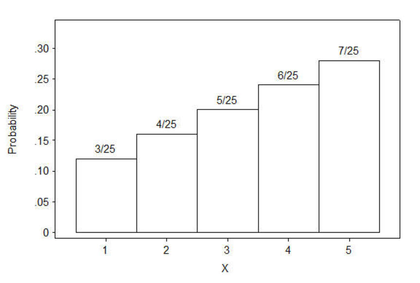

### Larger standard deviation?

Distribution A

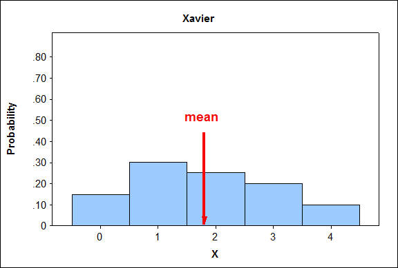

Distribution B

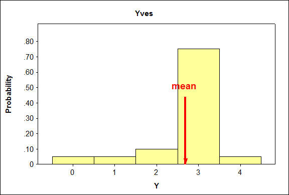

### Larger standard deviation?

Distribution A

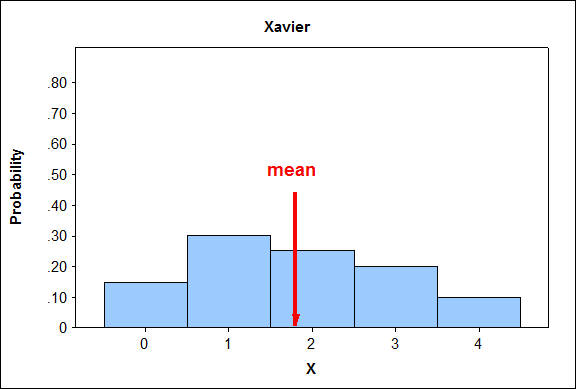

- values are farther from the mean
- larger standard deviation

Distribution B

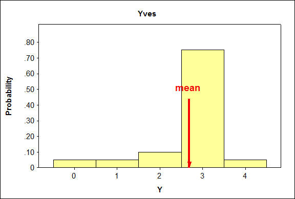

- values are closer to the mean
- smaller standard deviation

### Example defining RV by formula

[Ladislaus von Bortkiewicz](https://lvb.wiwi.hu-berlin.de/lvb)

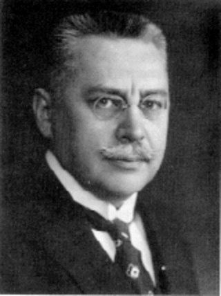

1868 - 1931

The Poisson distribution for **rare** and **independent** events

\[ P(X = x ) = \frac{\lambda^x}{x!} e^{-\lambda} \]

where \( \lambda \) is the **rate** an event occurs.

“The Law of Small Numbers” (Bortkiewicz, 1898)

### Example defining RV by formula

[Ladislaus von Bortkiewicz](https://lvb.wiwi.hu-berlin.de/lvb)

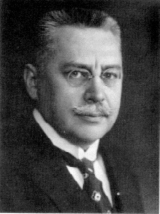

1868 - 1931

\[ P(X = x ) = \frac{\lambda^x}{x!} e^{-\lambda} \]

- [The number of](http://en.wikipedia.org/wiki/Poisson_distribution) …
  - Prussian soldiers killed by horse kicks over 20 years.
  - phone calls to technical support received per hour,
  - radioactive decays per second from a banana, or
  - taxis passing a street corner per hour.

### Using Probability Distributions

A random sample of graduating seniors was surveyed just before graduation. How many times did you change majors?

```r
x       |   0|   1|   2|   3|   4|   5|
--------+----+----+----+----+----+----|
P(X = x)| .28| .37| .23| .09| .02| .01|
```

What is the probability that a randomly selected senior has changed majors more than once?

\[ \begin{aligned} P(X > 1) & = P(X = 2) + P(X = 3 ) + P(X = 4 ) + P(X = 5 ) \\ & = .23 + .09 + .02 + .01 = 0.35 \end{aligned} \]

### Using Probability Distributions

A random sample of graduating seniors was surveyed just before graduation. How many times did you change majors?

```r
x       |   0|   1|   2|   3|   4|   5|
--------+----+----+----+----+----+----|
P(X = x)| .28| .37| .23| .09| .02| .01|
```

What is the probability that a randomly selected senior has changed majors more than once?

\[ \begin{aligned} P(X > 1) & = 1 - P(X \le 1) \\ & = 1 - \left( P(X = 0) + P(X = 1) \right) \\ & = 1 - \left( .28 + .37 \right ) = .35 \end{aligned} \]

### Key words (p. 131)

| Key Words | Meaning | Symbols | Values for X |
| --- | --- | --- | --- |
| more than 2 | strictly larger than 2 | X > 2 | 3, 4, 5 |
| no more than 2 | 2 or fewer | X ≤ 2 | 0, 1, 2 |
| fewer than 2 | strictly smaller than 2 | X < 2 | 0, 1 |
| no less than 2 | 2 or more | X ≥ 2 | 2, 3, 4, 5 |
| at least 2 | 2 or more | X ≥ 2 | 2, 3, 4, 5 |
| at most 2 | 2 or fewer | X ≤ 2 | 0, 1, 2 |
| exactly 2 | 2, no more or no less, only 2 | X = 2 | 2 |

### Example

A random sample of graduating seniors was surveyed just before graduation. How many times did you change majors?

```r
x       |   0|   1|   2|   3|   4|   5|
--------+----+----+----+----+----+----|
P(X = x)| .28| .37| .23| .09| .02| .01|
```

Do you think it would be unusual to change majors 4 or more times?

\( P(X \ge 4) = .03 \). So, 3% of the time a student changes majors 4 or more times. This means that it is fairly unusual to do so.

### Conditional Probability too

```r
x       |   0|   1|   2|   3|   4|   5|
--------+----+----+----+----+----+----|
P(X = x)| .28| .37| .23| .09| .02| .01|
```

What is the probability that a student who has changed majors, has changed majors more than three times?

\[ \begin{aligned} P( X > 3 | X \ge 1) & = \frac{ P(X > 3 \text{ and } X \ge 1)}{P(X \ge 1)} \\ & = \frac{ P(X > 3)}{1 - P(X = 0)} = \frac{.03}{1-.28} = 0.042 \end{aligned} \]

### Expected Value

Let \( E[X] \) be the **expected value** of the random variable \( X \).

For a **discrete** random variable \( X \) with possible values \( S \):

\[ E[X] = \sum_{x \in S} x \cdot P(X = x) \]

This is the just the **mean** calculated as a **weighted average**.

### Expected Value

```r
x       |   0|   1|   2|   3|   4|   5|
--------+----+----+----+----+----+----|
P(X = x)| .28| .37| .23| .09| .02| .01|
```

\[ \begin{aligned} E[X] & = \sum_{x \in S} x \cdot P(X = x) \\ & = ~ 0 \cdot P(X=0) + 1 \cdot P(X = 1) \\ & ~ + \! 2 \cdot P(X=2) + 3 \cdot P(X = 3 ) \\ & ~ + \! 4 \cdot P(X=4) + 5 \cdot P(X=5) \\ & = ~ 0 \times .28 + 1 \times .37 + 2 \times .23 \\ & ~ + \! 3 \times .09 + 4 \times .02 + 5 \times .01 = 1.23 \end{aligned} \]

### Expected Value

```r
x       |   0|   1|   2|   3|   4|   5|
--------+----+----+----+----+----+----|
P(X = x)| .28| .37| .23| .09| .02| .01|
```

\[ \begin{aligned} E[X] & = \sum_{x \in S} x \cdot P(X = x) \\ & = ~ 0 \times .28 + 1 \times .37 + 2 \times .23 \\ & ~ + \! 3 \times .09 + 4 \times .02 + 5 \times .01 = 1.23 \end{aligned} \]

implying that we expect a college student to change his or her major 1.23 times on average.

### Agenda

1. Homework comments
2. Checkpoint #11 results
3. Lecture 10 (covers pp. 124-137)
   - Checkpoint 12: Random variables (RVs) and distributions
   - **Checkpoint 13: Expection and variance rules** (Will cover Friday, checkpoint now due on Monday.)